# 1.Descarrega

Erola Fenollosa

13/12/2021

## Introducció i descarrega de paquets

L'objectiu d'aquest codi és la descàrrega de les dades de iNaturalist i el filtratge i neteja de les mateixes amb R. És el primer pas del cicle d'anàlisi de les dades. L'adquisició i revisió d'aquestes. El projecte de iNaturalist del qual volem descarregar la informació és: https://www.inaturalist.org/projects/especies-susceptibles-a-ser-invasores-a-barcelona-actuem-a-temps?tab=observations&subtab=table.

Un dels paquets que podem requerir és 'rinat' https://github.com/ropensci/rinat, Un paquet desenvolupat per accedir a les dades de 'iNaturalist' a través de APIs.

Carreguem els paquets necesaris:

```r
#install.packages("rinat")
library(rinat)
```

```r
library(ggplot2)
library(dplyr)
```

Més info i exemples sobre el paquet rinat:

```r
# vignette("rinat-intro", package = "rinat")
```

### 1. Descàrrega de les dades del Projecte a iNaturalist

Per a descarregar les dades del projecte podem utilitzar la funció get_inat_obs_project() del paquet rinat. Amb el parametre type indiquem que volem descarregar les observacions i amb Raw = false descarreguem un datarfame.

```r
act <- get_inat_obs_project("especies-susceptibles-a-ser-invasores-a-barcelona-actuem-a-temps", type = "observations", raw=FALSE)
```

```
## 1435 records
```

```
## Getting records 0-200
```

```
## Getting records up to 400
```

```
## Getting records up to 600
```

```
## Getting records up to 800
```

```
## Getting records up to 1000
```

```
## Getting records up to 1200
```

```
## Getting records up to 1400
```

```
## Getting records up to 1600
```

```
## Done.
```

### 2. Revisem el dataset

Visualitzem els noms de les variables del dataset descarregat

```r
names(act)
```

```
##  [1] "id"                                "observed_on"
##  [3] "description"                       "latitude"
##  [5] "longitude"                         "map_scale"
##  [7] "timeframe"                         "species_guess"
##  [9] "user_id"                           "taxon_id"
## [11] "created_at"                        "updated_at"
## [13] "place_guess"                       "id_please"
## [15] "observed_on_string"                "iconic_taxon_id"
## [17] "num_identification_agreements"     "num_identification_disagreements"
## [19] "time_observed_at"                  "time_zone"
## [21] "location_is_exact"                 "delta"
## [23] "positional_accuracy"               "private_latitude"
## [25] "private_longitude"                 "geoprivacy"
## [27] "quality_grade"                     "positioning_method"
## [29] "positioning_device"                "out_of_range"
```

[output cut: 22 more lines]

Comptabilitzem el nombre de registres considerant la data actual:

```r
print(paste("El nombre de registres actual (En data:", Sys.Date(), ") del projecte és: ", dim(act)[1]))
```

```
## [1] "El nombre de registres actual (En data: 2021-12-13 ) del projecte és:  1435"
```

### 3. Explorem el contingut del dataset

Revisem els rangs de les diferents variables numèriques Fem un histograma:

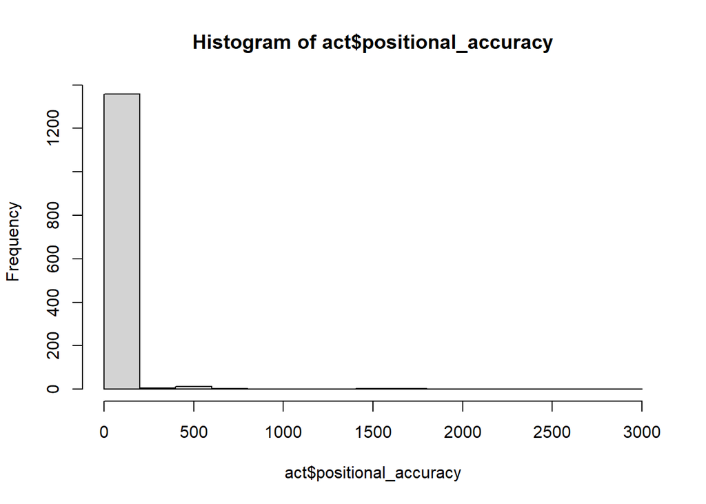

```r
hist(act$positional_accuracy)
```

```r
max(act$positional_accuracy, na.rm = TRUE)
```

```
## [1] 2916
```

Penso que seria necesari filtrar i eliminar aquells registres que no tenen una precisió inferior a 300m per exemple. Revisem quants registres hi ha discretitzant la variable:

```r
Categories <- cut(act$positional_accuracy, breaks = c(-Inf,10,50, 100, 300,Inf), labels = c("<10","10-50","50-100", "100-300", ">300"))
table(Categories)
```

```
## Categories
##     <10   10-50  50-100 100-300    >300
##    1164     152      29      15      31
```

Sembla que hi ha 31 registres amb massa poca precisió (> 300m). Eliminem aquests registres:

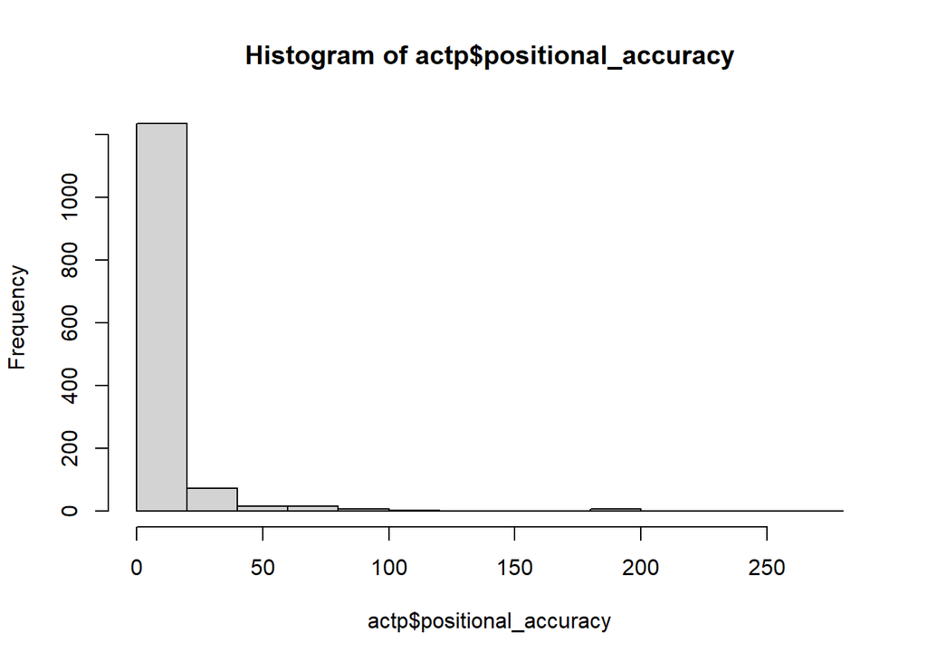

```r
actp <- act[act$positional_accuracy < 300,]
hist(actp$positional_accuracy)
```

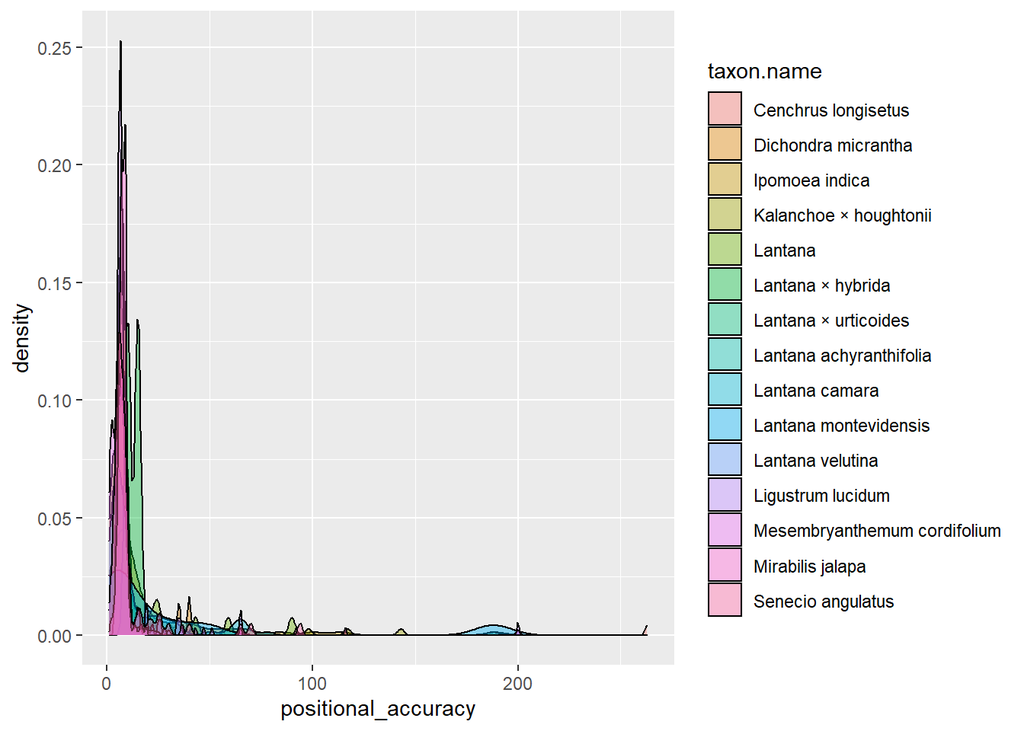

```r
ggplot(actp, aes(x=positional_accuracy, fill=taxon.name)) +
  geom_density(alpha=0.4)
```

Sembla que tenim registres sene nom d'espècie, amb NA

```r
unique(actp$taxon.name)
```

```
##  [1] "Cenchrus longisetus"          "Kalanchoe × houghtonii"
##  [3] "Ligustrum lucidum"            "Dichondra micrantha"
##  [5] "Senecio angulatus"            "Mirabilis jalapa"
##  [7] "Mesembryanthemum cordifolium" NA
##  [9] "Lantana camara"               "Lantana"
## [11] "Lantana montevidensis"        "Ipomoea indica"
## [13] "Lantana × urticoides"         "Lantana × hybrida"
## [15] "Lantana achyranthifolia"      "Lantana velutina"
```

Contem-los:

```r
sum(is.na(actp$taxon.name))
```

```
## [1] 44
```

Eliminem aquells registres que no tenen nom d'especie:

```r
actpn <- actp[!is.na(actp$taxon.name),]
sum(is.na(actpn$taxon.name))
```

```
## [1] 0
```

Revisem el nombre de registres en el temps. Primer transformem la data

```r
actpn$observed_on_DATE <- as.Date(actpn$observed_on)
```

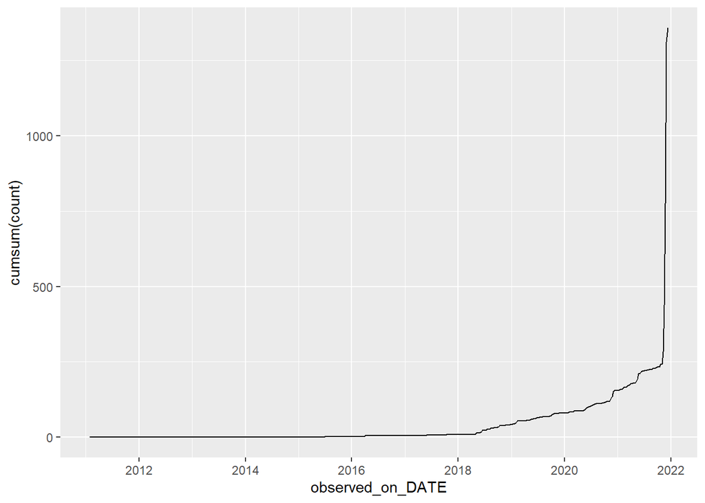

```r
ggplot(actpn, aes(observed_on_DATE))+stat_bin(aes(y=cumsum(..count..)),geom="line",bins=500)
```

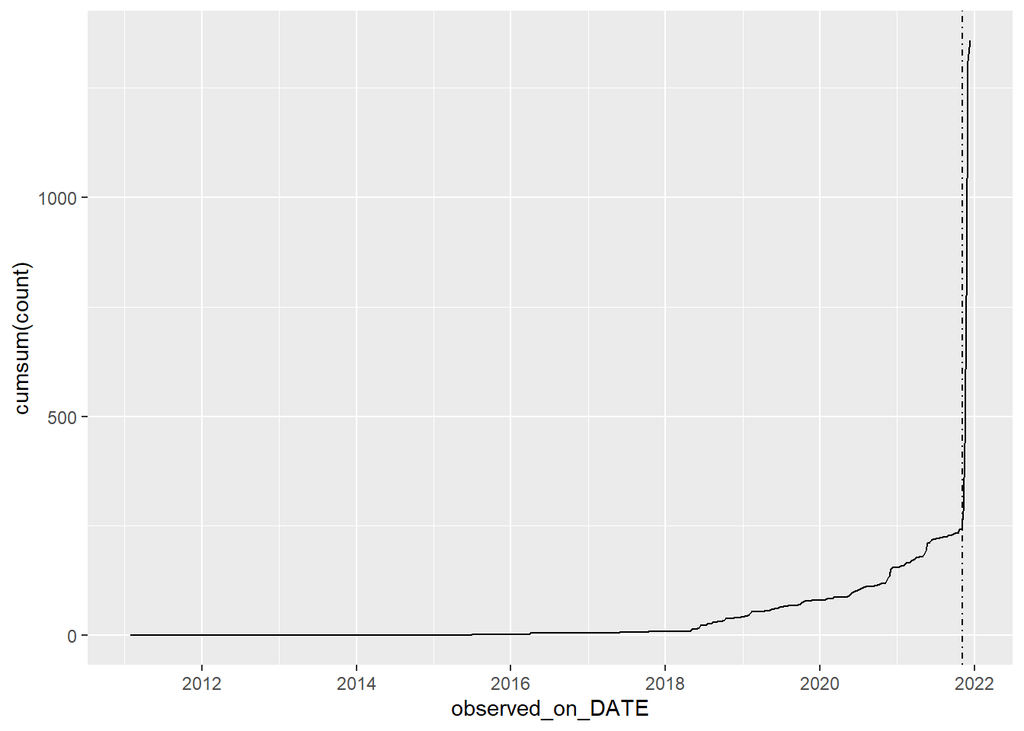

```r
ggplot(actpn, aes(observed_on_DATE))+stat_bin(aes(y=cumsum(..count..)),geom="line",bins=500) + geom_vline(xintercept=as.Date("2021-11-06"), linetype=4)
```

Vegem-ho amb nombres absoluts:

```r
a <- cut(actpn$observed_on_DATE, breaks = as.Date(c("2001-11-06", "2021-11-06", "2022-11-06")), labels = c("Abans d'iniciar el projecte","Després d'iniciar el projecte"))
table(a)
```

```
## a
##   Abans d'iniciar el projecte Després d'iniciar el projecte
##                           245                          1112
```

Quants registres totals hi ha de cada espècie?

```r
actpn %>% count(taxon.name, sort = TRUE)
```

```
##                      taxon.name   n
## 1  Mesembryanthemum cordifolium 336
## 2           Dichondra micrantha 266
## 3              Mirabilis jalapa 201
## 4             Ligustrum lucidum 134
## 5        Kalanchoe × houghtonii  86
## 6                Lantana camara  84
## 7           Cenchrus longisetus  79
## 8             Senecio angulatus  66
## 9                Ipomoea indica  59
## 10                      Lantana  32
## 11        Lantana montevidensis  10
## 12            Lantana × hybrida   2
## 13         Lantana × urticoides   1
## 14      Lantana achyranthifolia   1
## 15             Lantana velutina   1
```

Grafiquem:

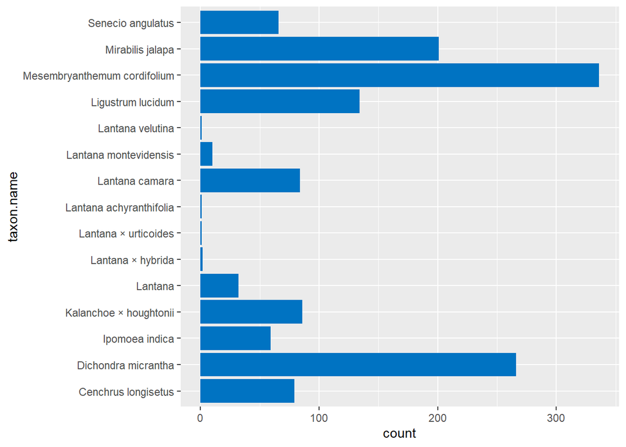

```r
ggplot(actpn, aes(taxon.name)) +
  geom_bar(fill = "#0073C2FF") + coord_flip()
```